# R Notebook

Analyzing growth. First setup the dataframe that will be used. We load the libraries we will use and read in the csv file.

```r
library(ggplot2)
library(dplyr)
library(lubridate)
library(reshape2)
growth <- read.csv(file='C:/Users/Ruben.Sikkes/Downloads/Growth.csv', header=T)
# up until colomn 12 because after is for now not needed and exclude empty rows at the bottom
growth <- growth[3:(which(is.na(growth$Weight))[1]-1),1:12]
# parse date and create a column for days.
growth$Date <- parse_date_time(growth$Date, "%d/%m/%y")
growth$Wday <- wday(growth$Date)
growth$day_since_start <- as.double(difftime(growth$Date, growth$Date[1], units = 'days'))
head(growth)
```

|  | Date | Weight | fatpct | watpct | musclepct | botgewicht | musclemass | muscgain | fatmass | fatgain | watmass | watgain | Wday | day_since_start |
| --- | --- | --- | --- | --- | --- | --- | --- | --- | --- | --- | --- | --- | --- | --- |
| 3 | 2017-11-17 | 74.4 | 13.6 | 63.6 | 40.7 | 3.6 | 30.2808 | 0.00000 | 10.1184 | 0.00000 | 47.3184 | 0.00000 | 6 | 0 |
| 4 | 2017-11-18 | 73.9 | 13.5 | 63.7 | 40.7 | 3.6 | 30.0773 | -0.20350 | 9.9765 | -0.14190 | 47.0743 | -0.24410 | 7 | 1 |
| 5 | 2017-11-20 | 74.4 | 13.6 | 63.6 | 40.7 | 3.6 | 30.2808 | 0.10175 | 10.1184 | 0.07095 | 47.3184 | 0.12205 | 2 | 3 |
| 6 | 2017-11-21 | 75.0 | 13.8 | 63.4 | 40.6 | 3.6 | 30.4500 | 0.16920 | 10.3500 | 0.23160 | 47.5500 | 0.23160 | 3 | 4 |
| 7 | 2017-11-22 | 74.9 | 13.8 | 63.4 | 40.6 | 3.6 | 30.4094 | -0.04060 | 10.3362 | -0.01380 | 47.4866 | -0.06340 | 4 | 5 |
| 8 | 2017-11-23 | 74.6 | 13.7 | 63.5 | 40.6 | 3.6 | 30.2876 | -0.12180 | 10.2202 | -0.11600 | 47.3710 | -0.11560 | 5 | 6 |

Now for a table view here’s an indication of raw and percentual changes measured. How has my composition and raw stats changed?

```r
# composition beginning vs end
change_df_pct = data.frame("fat_pct" = c(growth$fatpct[1], growth$fatpct[length(growth$day_since_start)]),
                      "muscle_pct"= c(growth$musclepct[1], growth$musclepct[length(growth$day_since_start)]),
                      "wat_pct"= c(growth$watpct[1], growth$watpct[length(growth$day_since_start)]))
change_df_pct[3,] <- change_df_pct[2,]-change_df_pct[1,]
row.names(change_df_pct) <- c("Before", "Current", "Change")
head(change_df_pct)
```

|  | fat_pct | muscle_pct | wat_pct |
| --- | --- | --- | --- |
| Before | 13.6 | 40.7 | 63.6 |
| Current | 15.7 | 39.8 | 62.0 |
| Change | 2.1 | -0.9 | -1.6 |

```r
change_df_raw <- data.frame("fatmass" = c(growth$fatmass[1], growth$fatmass[length(growth$day_since_start)]),
                      "musclemass"= c(growth$musclemass[1], growth$musclemass[length(growth$day_since_start)]),
                      "watmass"= c(growth$watmass[1], growth$watmass[length(growth$day_since_start)]))
change_df_raw[3,] <- change_df_raw[2,]-change_df_raw[1,]
row.names(change_df_raw) <- c("Before", "Current", "Change")
head(change_df_raw)
```

|  | fatmass | musclemass | watmass |
| --- | --- | --- | --- |
| Before | 10.1184 | 30.2808 | 47.3184 |
| Current | 12.7484 | 32.3176 | 50.3440 |
| Change | 2.6300 | 2.0368 | 3.0256 |

Now to plot some basic things as how weight changes over time.

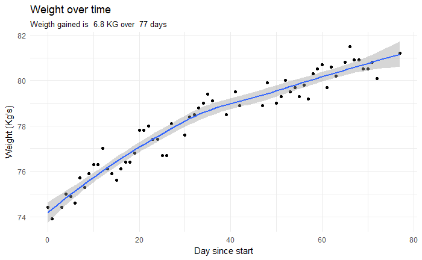

```r
ggplot(growth, aes(x=day_since_start,y=Weight)) + geom_point() + geom_smooth()+ theme_minimal()+
  labs(x="Day since start", y = "Weight (Kg's)", title="Weight over time",
       subtitle= paste("Weigth gained is ",
                       round(growth$Weight[length(growth$Weight)]-growth$Weight[1], digits=2),
                       "KG over ",max(growth$day_since_start),"days"))
```

We can see that weight increases and is starting to stagnate.

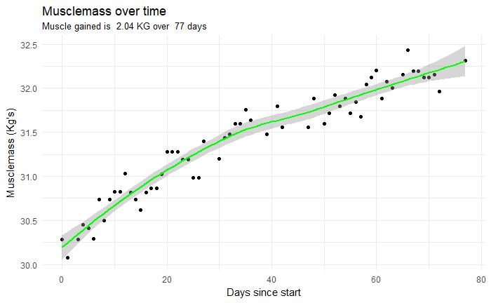

```r
ggplot(growth, aes(x=day_since_start,y=musclemass)) +
  geom_point() +
  geom_smooth(color='green')+ theme_minimal()+
  labs(x="Days since start", y = "Musclemass (Kg's)", title="Musclemass over time",
  subtitle= paste("Muscle gained is ", round(growth$musclemass[length(growth$musclemass)]-growth$musclemass[1], digits=2),
                       "KG over ",max(growth$day_since_start),"days"))
```

Similarly we can see that musclemass increases but stagnates. Idem for fatmass below.

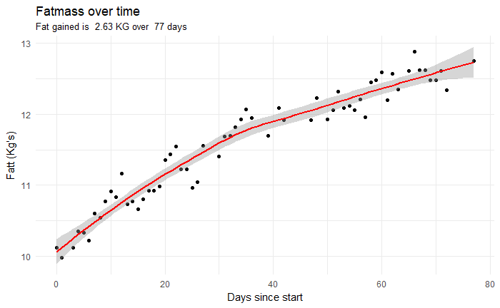

```r
ggplot(growth, aes(x=day_since_start,y=fatmass)) + geom_point() + geom_smooth(color='red')+ theme_minimal()+
  labs(x="Days since start", y = "Fatt (Kg's)", title="Fatmass over time", subtitle= paste("Fat gained is ", round(growth$fatmass[length(growth$fatmass)]-growth$fatmass[1], digits=2),
                       "KG over ",max(growth$day_since_start),"days"))
```

Now taking into consideration the gain per day of the different variables, we create new variables showing the difference compared to timestep 0 and create a new melted dataframe for plotting.

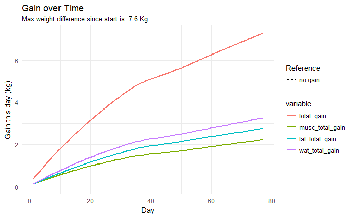

```r
growth$total_gain <- growth$Weight- growth$Weight[2]
growth$musc_total_gain <- growth$musclemass- growth$musclemass[2]
growth$fat_total_gain <- growth$fatmass- growth$fatmass[2]
growth$wat_total_gain <- growth$watmass- growth$watmass[2]
# makes it easier to plot (with correct legend)
temp <- growth[2:nrow(growth),15:18]
temp2 <- melt(temp)
temp2$day <- rep(growth$day_since_start[2:nrow(growth)], times=4)
ggplot(temp2) +
  geom_smooth(aes(x=day, y= value, colour=variable), se=F, method = "loess") +
  labs(title= "Gain over Time", x= "Day", y = "Gain this day (kg)",
       subtitle= paste( "Max weight difference since start is " , round(max(growth$total_gain[2:nrow(growth)]),3), "Kg")) +
  geom_hline(aes(yintercept = 0, linetype="no gain")) +
  scale_linetype_manual(name = "Reference",values = c(2, 2)) +
  theme_minimal()
```

Now looking more specifically at weight change per day we get the following graph.

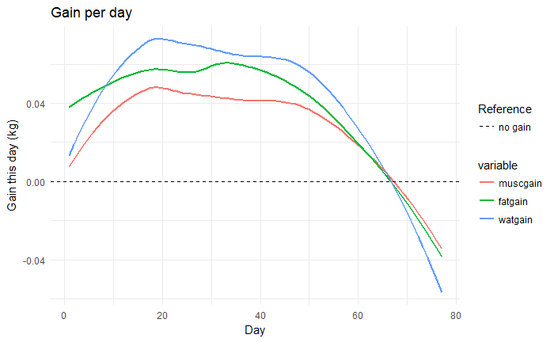

```r
day_length= length(growth$Date)
dd_sub = growth[2:day_length,c(8,10,12)]
day_length= length(growth$Date)
dd = melt(dd_sub)
dd$day <- rep(growth$day[2:day_length], times=3)
ggplot(dd) +
  geom_smooth(aes(x=day, y= value, colour=variable), se=F) +
  labs(title= "Gain per day", x= "Day", y = "Gain this day (kg)") +
  geom_hline(aes(yintercept = 0, linetype="no gain")) +
  scale_linetype_manual(name = "Reference",values = c(2, 2)) +
  theme_minimal()
```

We quickly notice that smoothed gain has been good untill around day 65. After day 65 i seem to be showing losses. Good though is that most extreme losses are water and not muscle!

Side question: is there a difference in day of the week and gain?

```r
growth%>% group_by(Wday) %>% summarize(sum= sum(muscgain))
```

| Wday | sum |
| --- | --- |
| 1 | 0.6532000 |
| 2 | 1.0341500 |
| 3 | -0.3289333 |
| 4 | 0.2078000 |
| 5 | 0.7676500 |
| 6 | 0.3983400 |
| 7 | -0.9416500 |

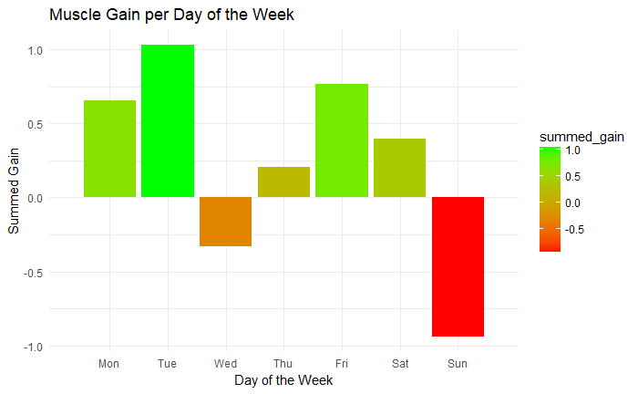

```r
growth%>% group_by(Wday) %>% summarize(summed_gain= sum(muscgain)) %>% ggplot() +
  geom_col(aes(x=Wday, y= summed_gain, fill=summed_gain))+
  scale_fill_gradient(low ="red", high= "green")+ theme_minimal() +
  labs(x= "Day of the Week", y = "Summed Gain", title="Muscle Gain per Day of the Week")+
  xlim(labels = c("Mon", "Tue", "Wed", "Thu", "Fri", "Sat", "Sun"))
```

Next: how will my weight change the next 14 days? We use a simple regression model based on weight and time.

```r
# create the model which we will use
fit <- lm(Weight~poly(day_since_start,1)+ poly(day_since_start,2),data=growth)
#summary(fit) # display model results if you want
# Create a dataframe for prediction
new_x <- as.data.frame(day_since_start<- max((growth$day_since_start)+1):(max(growth$day_since_start)+14))
# predict new values
predicted_weight <- predict(fit, new_x)
```

```
prediction from a rank-deficient fit may be misleading
```

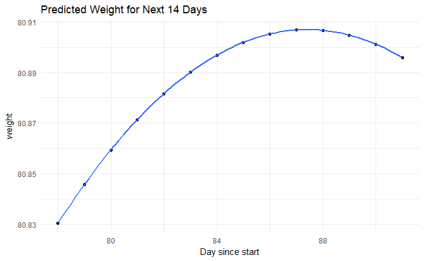

```r
# and plot results
ggplot() + geom_point(aes(x=new_x, y = predicted_weight))+ geom_smooth(aes(x=new_x, y = predicted_weight))+
  labs(x='Day since start', y='weight', title = 'Predicted Weight for Next 14 Days') + theme_minimal()
```

```r
#tail(predicted_weight) #  show predicted results if you like
```

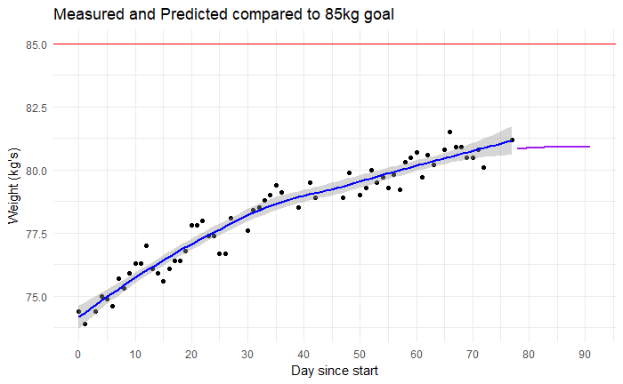

```r
ggplot() + geom_point(aes(x=day_since_start, y = Weight), data=growth) +
  geom_smooth(aes(x=day_since_start, y = Weight),color='blue', data=growth, method ='loess') +
  geom_smooth(aes(x=new_x, y = predicted_weight), color='purple')+
  theme_minimal()+
  labs(title='Measured and Predicted compared to 85kg goal', x="Day since start", y = "Weight (kg's)")+
  geom_hline(yintercept=85, color='red')+
  scale_x_continuous(breaks=seq(0,100,10))
```

So how about the ratio between fatgain and muscle gain? How has my bulk been? We can visualize this by the ratio of Musclegain/Fatgain.

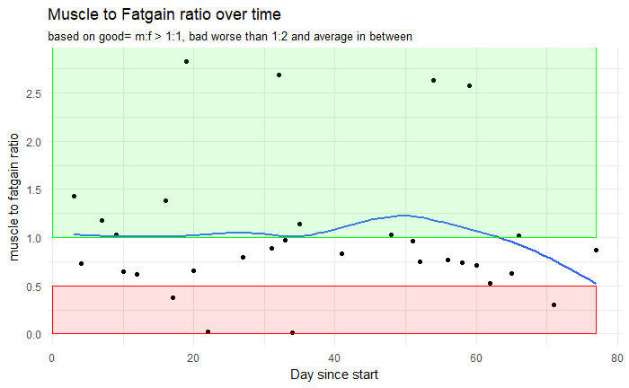

```r
growth$mf_gain_ratio <- growth$muscgain/ growth$fatgain
growth %>% filter(muscgain>0) %>% ggplot(aes(x=day_since_start, y= mf_gain_ratio)) +
  geom_point() +
  geom_smooth(se=F)+
  theme_minimal()+
  scale_y_continuous(breaks = seq(0,3,0.5) )+
  labs(x="Day since start", y= "muscle to fatgain ratio", title='Muscle to Fatgain ratio over time', subtitle= "based on good= m:f > 1:1, bad worse than 1:2 and average in between")+
  geom_rect(xmin=0, ymin=0, xmax=max(growth$day_since_start),ymax=0.5, colour="red", fill="red", alpha=0.005)+
  geom_rect(xmin=0, ymin=1, xmax=max(growth$day_since_start),ymax=3, colour="green", fill="green", alpha=0.005)
```

Next we show that comparing how many dots are in each box we see that most is in blue (middle) and thereafter green (good).

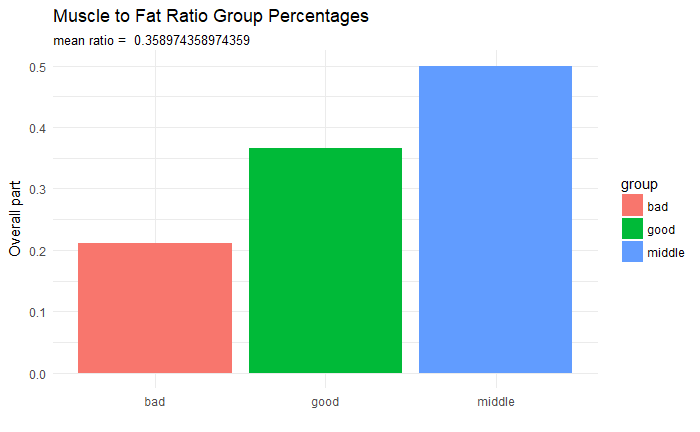

```r
bad_pct = sum(growth$mf_gain_ratio<0.5, na.rm=T)/ sum(growth$mf_gain_ratio>0, na.rm=T)
good_pct = sum(growth$mf_gain_ratio>1, na.rm=T)/ sum(growth$mf_gain_ratio>0, na.rm=T)
middle_pct= sum(growth$mf_gain_ratio>0.5 & growth$mf_gain_ratio<1, na.rm=T)/ sum(growth$mf_gain_ratio>0, na.rm=T)
gain_df = data.frame('ratio'= c(bad_pct,middle_pct,good_pct), group=c('bad','middle', 'good'))
ggplot(data=gain_df, aes(x=group, y=ratio, fill=group)) + geom_col() +
  labs(x= "", y='Overall part', title='Muscle to Fat Ratio Group Percentages', subtitle= paste("mean ratio = ", mean(gain_df$ratio))) + theme_minimal()
```

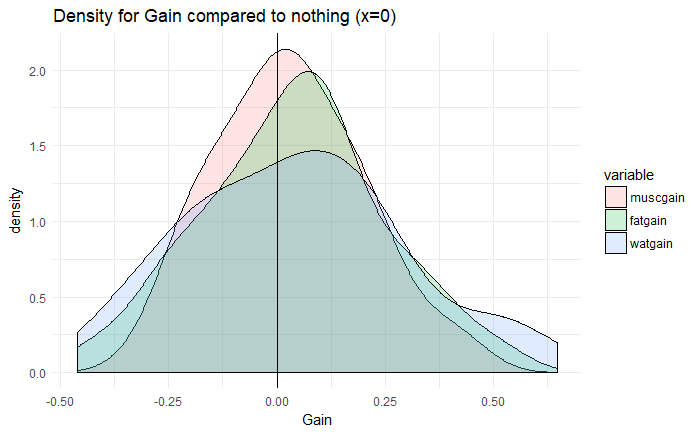

```r
ggplot(data= dd, aes(x=value, fill=variable)) +
  geom_density(alpha=0.2) +
  geom_vline(xintercept = 0)+
  theme_minimal() +
  labs(x='Gain', title= 'Density for Gain compared to nothing (x=0)')
```

So whats the relation between eating more and gain? Does having a bigger surplus indeed result in a worse muscle/fat gain ratio?

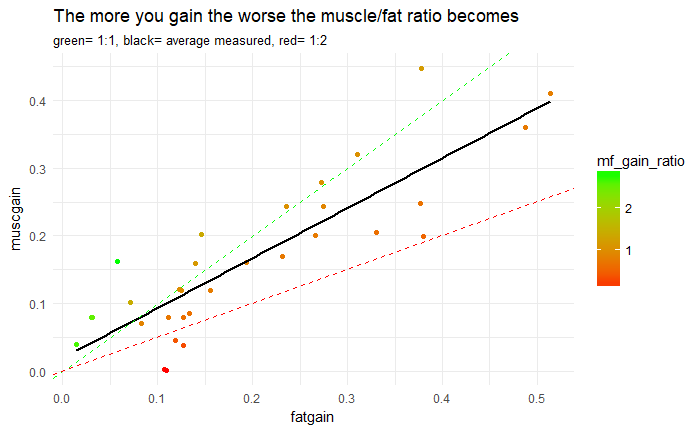

```r
growth %>% filter(muscgain>0) %>% ggplot() + geom_point(aes(x=fatgain, y = muscgain, colour= mf_gain_ratio)) +
  geom_smooth(aes(x=fatgain, y = muscgain), colour="black", method ="lm", se=F) +
  geom_abline(slope=1, colour= "green", linetype=2) +
  geom_abline(slope=0.5, colour="red", linetype=2)+
  labs(title= "The more you gain the worse the muscle/fat ratio becomes", subtitle="green= 1:1, black= average measured, red= 1:2") + theme_minimal() + scale_colour_gradient(low ="red", high= "green")
```

The best points are definately in the left-bottom corner and moving to the right, the black line moves closer to the red dashed line (a bad ratio). Gain should, for an ideal ratio, therefore be minimized.

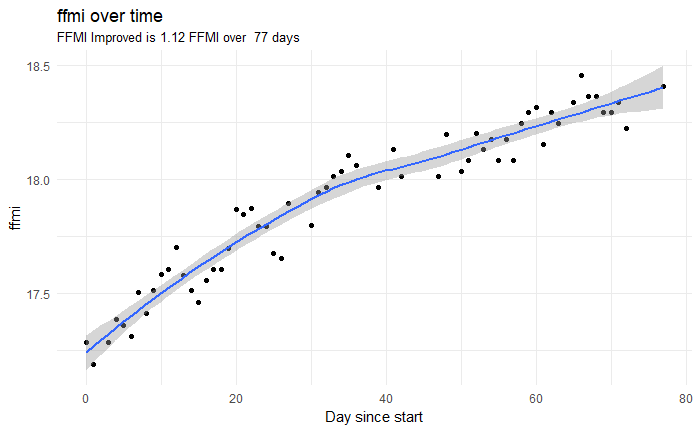

```r
growth$lean_weight <- growth$Weight * (1-(growth$fatpct /100))
growth$ffmi <- (growth$lean_weight/2.2)/(((6*12)+4)*0.0254)^2*2.20462
growth$adj_ffmi <- growth$ffmi + (6.1 * (1.8 - ((6 * 12.0 + 4) * 0.0254)))
ggplot(growth, aes(x=day_since_start,y=ffmi)) + geom_point() + geom_smooth()+ theme_minimal()+
  labs(x="Day since start", y = "ffmi", title="ffmi over time",
       subtitle= paste("FFMI Improved is",
                       round(growth$ffmi[length(growth$ffmi)]-growth$ffmi[1], digits=2),
                       "FFMI over ",max(growth$day_since_start),"days"))
```

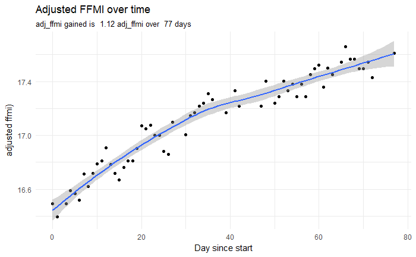

```r
ggplot(growth, aes(x=day_since_start,y=adj_ffmi)) + geom_point() + geom_smooth()+ theme_minimal()+
  labs(x="Day since start", y = "adjusted ffmi)", title="Adjusted FFMI over time",
       subtitle= paste("adj_ffmi gained is ",
                       round(growth$adj_ffmi[length(growth$adj_ffmi)]-growth$adj_ffmi[1], digits=2),
                       "adj_ffmi over ",max(growth$day_since_start),"days"))
```

There fore based on FFMi indexes:  
* 16 - 17: below average  
* 18 - 19: average  
* 20 - 21: above average  
* 22 - 23: excellent  
* 23 - 25: superior  
* 26 - 27: scores considered suspicious but still attainable naturally  
* 28 - 30: highly unlikely scores to be obtained naturally without steroid usage

still average since im around 18.2 for normal and even below average for adj_ffmi.